# RandomForestExample

Pedro Beschoren da Costa

2023-06-07

# load libraries

install packages individually as necessary

```r
#load packages
library(phyloseq)
library(Boruta)
library(caret)
library(dplyr)
library(tibble)
library(ranger)
library(metagMisc)
library(purrr)
#load a bunch fo custom functions that will helps us
source("./Code/Machine_Learning_custom_functions.R")
```

# load microbiome data as a phyloseq object

a phyloseq object is only a data container, with layers for the feature table (ASVs/OTUs), microbial taxonomies, sample metadata, and reference sequences.

```r
# load object
load("./Data/ps_rarefied.Rdata")

#check ps object
ps_rarefied # full ps object
```

```
## phyloseq-class experiment-level object
## otu_table()   OTU Table:         [ 500 taxa and 143 samples ]
## sample_data() Sample Data:       [ 143 samples by 44 sample variables ]
## tax_table()   Taxonomy Table:    [ 500 taxa by 7 taxonomic ranks ]
## refseq()      DNAStringSet:      [ 500 reference sequences ]
```

```r
otu_table(ps_rarefied)[1:5,1:5] # otu table
```

```
## OTU Table:          [5 taxa and 5 samples]
##                      taxa are rows
##         49_16S 50_16S 51_16S 52_16S 53_16S
## bASV_5      90    299    109     87    231
## bASV_7      25    156    154    446     58
## bASV_9     157    191    264    108    145
## bASV_11    337    248    193    216    100
## bASV_12    201    437    272     71    154
```

```r
tax_table(ps_rarefied)[1:5,] # taxonomy
```

```
## Taxonomy Table:     [5 taxa by 7 taxonomic ranks]:
##         Kingdom       Phylum                Class
## bASV_5  "k__Bacteria" "p__Proteobacteria"   "c__Gammaproteobacteria"
## bASV_7  "k__Bacteria" "p__Proteobacteria"   "c__Gammaproteobacteria"
## bASV_9  "k__Bacteria" "p__Bacteroidota"     "c__Bacteroidia"
## bASV_11 "k__Bacteria" "p__Proteobacteria"   "c__Alphaproteobacteria"
## bASV_12 "k__Bacteria" "p__Actinobacteriota" "c__Actinobacteria"
##         Order                 Family                 Genus
## bASV_5  "o__Burkholderiales"  "f__Comamonadaceae"    "g__Acidovorax"
## bASV_7  "o__Pseudomonadales"  "f__Pseudomonadaceae"  "g__Pseudomonas"
## bASV_9  "o__Chitinophagales"  "f__Chitinophagaceae"  "g__Niastella"
## bASV_11 "o__Sphingomonadales" "f__Sphingomonadaceae" "g__Sphingomonas"
## bASV_12 "o__Streptomycetales" "f__Streptomycetaceae" "g__Streptomyces"
##         ASV_id
## bASV_5  "bASV_5"
## bASV_7  "bASV_7"
## bASV_9  "bASV_9"
## bASV_11 "bASV_11"
## bASV_12 "bASV_12"
```

```r
ps_rarefied@sam_data [1:5,1:5]# metadata
```

```
##        Target Harvest_ID Block_row_column Sp_speed  Stress
## 49_16S    16S         49            1.2.4       M1 Control
## 50_16S    16S         50            2.3.1       M1 Control
## 51_16S    16S         51            3.2.9       M1 Control
## 52_16S    16S         52            4.1.6       M1 Control
## 53_16S    16S         53           5.6.14       M1 Control
```

```
## Square root transformation
## Wisconsin double standardization
## *** Best solution was not repeated -- monoMDS stopping criteria:
##      5: no. of iterations >= maxit
##     15: stress ratio > sratmax
```

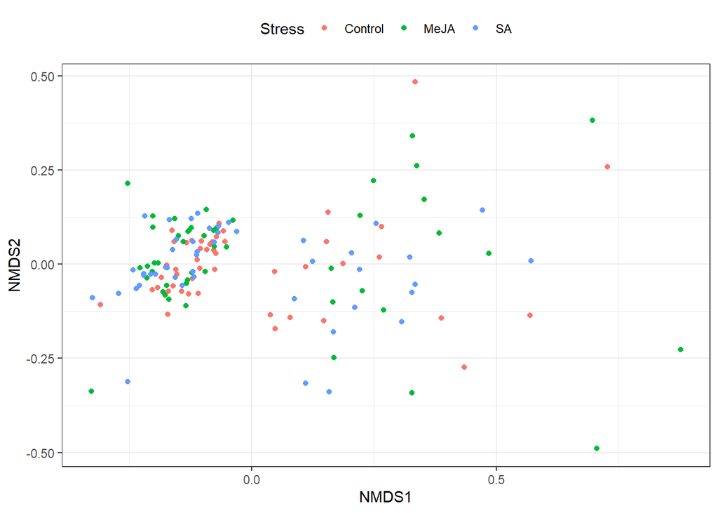

```r
#let's take a quick look on an oridnation  in this dataset
plot_ordination(ps_rarefied,
                ordination = ordinate(ps_rarefied, "NMDS", "bray"),
                type="samples",
                color="Stress")+ theme_bw()+
  theme(legend.position="top")
```

```
## Square root transformation
## Wisconsin double standardization
## *** Best solution was not repeated -- monoMDS stopping criteria:
##      8: no. of iterations >= maxit
##     12: stress ratio > sratmax
```

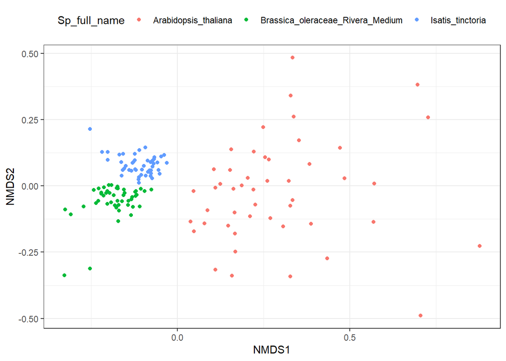

```r
plot_ordination(ps_rarefied,
                ordination = ordinate(ps_rarefied, "NMDS", "bray"),
                type="samples",
                color="Sp_full_name")+
  theme_bw()+
  theme(legend.position="top")
```

# put data into a format boruta will udenrstand

We will try to predict the variable “Stress”, present in our metadata, by using the abudannces of bacteria. “Stress” this refers to the stress treatments we applied to the plants in a greenhouse experiment with different plant species

for classification tasks in borutas, a most critical part of the df is having the variable that you want to predict as a factor. also, make sure you don’t ahve NAs, NaN, or empty values in your df

```r
# put that microbiome data into a df format that boruta will understand
df_for_boruta_stress<-single_physeq_to_borutaInput(physeq_object = ps_rarefied,
                                             variable_to_be_classified = "Stress")[,-1] # [,-1] removes first column, "sample" as a predictor
#check the object you have
df_for_boruta_stress[45:55,1:10]
```

```
##     Stress bASV_5 bASV_7 bASV_9 bASV_11 bASV_12 bASV_13 bASV_14 bASV_15 bASV_16
## 45      SA     39     33    359     280     127     360      89      41      19
## 46      SA     43     43    385     617      74     375      65      29      42
## 47      SA     44    156    485     509      99     517      25      39     138
## 48 Control     90     25    157     337     201     226     374     157      62
## 49 Control    299    156    191     248     437     178     159      49     373
## 50 Control    109    154    264     193     272      89     301      72     173
## 51 Control     87    446    108     216      71     162     230     135      96
## 52 Control     66     72     72      40     186     296     213     202     116
## 53 Control    231     58    145     100     154     115     321      26     144
## 54 Control    130    149    109      59     381     101     130      19     102
## 55 Control     21      7    127      25     481     172     395      68      45
```

```r
str(df_for_boruta_stress)
```

```
## 'data.frame':    143 obs. of  501 variables:
##  $ Stress  : Factor w/ 3 levels "Control","MeJA",..: 1 1 1 1 1 1 1 1 1 1 ...
##  $ bASV_5  : num  238 198 195 319 52 390 94 98 22 15 ...
##  $ bASV_7  : num  80 66 1076 111 32 ...
##  $ bASV_9  : num  264 310 153 257 356 224 250 472 292 242 ...
##  $ bASV_11 : num  337 279 132 260 487 227 184 416 341 286 ...
##  $ bASV_12 : num  71 70 53 367 98 116 75 60 81 55 ...
##  $ bASV_13 : num  382 633 498 295 477 488 281 484 427 426 ...
##  $ bASV_14 : num  76 102 123 111 85 130 118 94 106 43 ...
##  $ bASV_15 : num  49 20 24 74 23 23 37 16 61 33 ...
##  $ bASV_16 : num  48 74 26 100 53 68 64 40 88 124 ...
##  $ bASV_18 : num  232 238 126 127 163 130 179 165 123 198 ...
##  $ bASV_19 : num  151 189 265 124 300 314 131 153 96 157 ...
##  $ bASV_20 : num  156 171 588 57 65 139 76 77 12 48 ...
##  $ bASV_21 : num  81 109 91 42 94 125 95 101 79 156 ...
```

[output cut: 86 more lines]

```r
#are tehre any NAs?
any(is.na(df_for_boruta_stress))
```

```
## [1] FALSE
```

```r
#is the first column a factor?
is.factor(df_for_boruta_stress[,1])
```

```
## [1] TRUE
```

```r
df_for_boruta_stress[,1]
```

```
##   [1] Control Control Control Control Control Control Control Control Control
##  [10] Control Control Control Control Control Control Control MeJA    MeJA
##  [19] MeJA    MeJA    MeJA    MeJA    MeJA    MeJA    MeJA    MeJA    MeJA
##  [28] MeJA    MeJA    MeJA    MeJA    MeJA    SA      SA      SA      SA
##  [37] SA      SA      SA      SA      SA      SA      SA      SA      SA
##  [46] SA      SA      Control Control Control Control Control Control Control
##  [55] Control Control Control Control Control Control Control Control Control
##  [64] Control Control Control Control Control Control MeJA    MeJA    MeJA
##  [73] MeJA    MeJA    Control MeJA    MeJA    MeJA    MeJA    MeJA    MeJA
##  [82] MeJA    MeJA    MeJA    MeJA    Control MeJA    SA      SA      SA
##  [91] SA      SA      SA      SA      SA      SA      Control SA      SA
## [100] SA      SA      SA      SA      SA      Control Control Control Control
## [109] Control Control Control MeJA    MeJA    MeJA    MeJA    MeJA    MeJA
## [118] MeJA    MeJA    MeJA    MeJA    MeJA    MeJA    MeJA    MeJA    MeJA
## [127] MeJA    SA      SA      SA      SA      SA      SA      SA      SA
## [136] SA      SA      SA      SA      SA      SA      SA      SA
## Levels: Control MeJA SA
```

# run boruta

```r
set.seed(101) # set a fixed seed to have reproducible results
boruta_output_stress<-  Boruta(Stress~.,   # classification to predict
                           data = df_for_boruta_stress, # your df with the variable you want to predict
                           doTrace=2, #  verbosity level
                           maxRuns = 60,  # number of iterations
                           ntree = 20000) # size of the forest
```

```
##  1. run of importance source...
```

```
##  2. run of importance source...
```

```
##  3. run of importance source...
```

```
##  4. run of importance source...
```

```
##  5. run of importance source...
```

```
##  6. run of importance source...
```

```
##  7. run of importance source...
```

```
##  8. run of importance source...
```

```
##  9. run of importance source...
```

```
##  10. run of importance source...
```

```
##  11. run of importance source...
```

```
##  12. run of importance source...
```

```
##  13. run of importance source...
```

```
##  14. run of importance source...
```

```
##  15. run of importance source...
```

```
##  16. run of importance source...
```

```
## After 16 iterations, +2.8 mins:
```

```
##  rejected 487 attributes: bASV_100, bASV_101, bASV_102, bASV_103, bASV_104 and 482 more;
```

```
##  still have 13 attributes left.
```

```
##  17. run of importance source...
```

```
##  18. run of importance source...
```

```
##  19. run of importance source...
```

```
##  20. run of importance source...
```

```
##  21. run of importance source...
```

```
##  22. run of importance source...
```

```
##  23. run of importance source...
```

```
##  24. run of importance source...
```

```
##  25. run of importance source...
```

```
##  26. run of importance source...
```

```
##  27. run of importance source...
```

```
##  28. run of importance source...
```

```
## After 28 iterations, +3.4 mins:
```

```
##  confirmed 2 attributes: bASV_58, bASV_66;
```

```
##  still have 11 attributes left.
```

```
##  29. run of importance source...
```

```
##  30. run of importance source...
```

```
##  31. run of importance source...
```

```
##  32. run of importance source...
```

```
##  33. run of importance source...
```

```
##  34. run of importance source...
```

```
##  35. run of importance source...
```

```
##  36. run of importance source...
```

```
##  37. run of importance source...
```

```
##  38. run of importance source...
```

```
##  39. run of importance source...
```

```
##  40. run of importance source...
```

```
##  41. run of importance source...
```

```
##  42. run of importance source...
```

```
##  43. run of importance source...
```

```
##  44. run of importance source...
```

```
## After 44 iterations, +4.4 mins:
```

```
##  confirmed 1 attribute: bASV_314;
```

```
##  still have 10 attributes left.
```

```
##  45. run of importance source...
```

```
##  46. run of importance source...
```

```
##  47. run of importance source...
```

```
## After 47 iterations, +4.5 mins:
```

```
##  confirmed 1 attribute: bASV_72;
```

```
##  still have 9 attributes left.
```

```
##  48. run of importance source...
```

```
##  49. run of importance source...
```

```
##  50. run of importance source...
```

```
##  51. run of importance source...
```

```
##  52. run of importance source...
```

```
## After 52 iterations, +4.8 mins:
```

```
##  confirmed 1 attribute: bASV_190;
```

```
##  still have 8 attributes left.
```

```
##  53. run of importance source...
```

```
##  54. run of importance source...
```

```
##  55. run of importance source...
```

```
## After 55 iterations, +5 mins:
```

```
##  confirmed 1 attribute: bASV_359;
```

```
##  still have 7 attributes left.
```

```
##  56. run of importance source...
```

```
##  57. run of importance source...
```

```
##  58. run of importance source...
```

```
##  59. run of importance source...
```

```r
# It's a good practice to save  R objects that take a long time to compute so you don't have to re-run them later
save(boruta_output_stress, file = "./Results/boruta_output_stress.RData")
```

# check boruta object

```r
# this is out obruta object
boruta_output_stress
```

```
## Boruta performed 59 iterations in 5.146647 mins.
##  6 attributes confirmed important: bASV_190, bASV_314, bASV_359,
## bASV_58, bASV_66 and 1 more;
##  487 attributes confirmed unimportant: bASV_100, bASV_101, bASV_102,
## bASV_103, bASV_104 and 482 more;
##  7 tentative attributes left: bASV_175, bASV_320, bASV_341, bASV_362,
## bASV_477 and 2 more;
```

```r
#here you see the importance fo each feature. features with higher importance are better at predicting classifications than features with lwoer importance
attStats(boruta_output_stress)[50:60,]
```

```
##            meanImp   medianImp     minImp       maxImp  normHits  decision
## bASV_64  2.4098488  2.39088611 -0.3494970 4.418088e+00 0.0000000  Rejected
## bASV_65 -1.2824331 -1.08023443 -2.8213603 2.064772e-04 0.0000000  Rejected
## bASV_66 30.6844790 34.59154872 12.7354642 4.344690e+01 0.9491525 Confirmed
## bASV_67 27.1454319 33.49242439  4.8711126 3.931294e+01 0.7457627 Tentative
## bASV_68 -0.2862911  0.02558075 -2.4418715 7.718845e-01 0.0000000  Rejected
## bASV_69  2.4831364  2.31080944  0.4492204 5.190831e+00 0.0000000  Rejected
## bASV_70 -0.8279271 -0.60678203 -2.7379243 6.768681e-01 0.0000000  Rejected
## bASV_71  0.5852092  0.83260793 -1.2305913 1.831802e+00 0.0000000  Rejected
## bASV_72 31.2503047 36.77350855  9.2437123 4.430861e+01 0.8474576 Confirmed
## bASV_73 -0.7835898 -0.67452291 -2.8307522 1.809058e+00 0.0000000  Rejected
## bASV_74  0.4601957  0.09636367 -1.3427075 2.583994e+00 0.0000000  Rejected
```

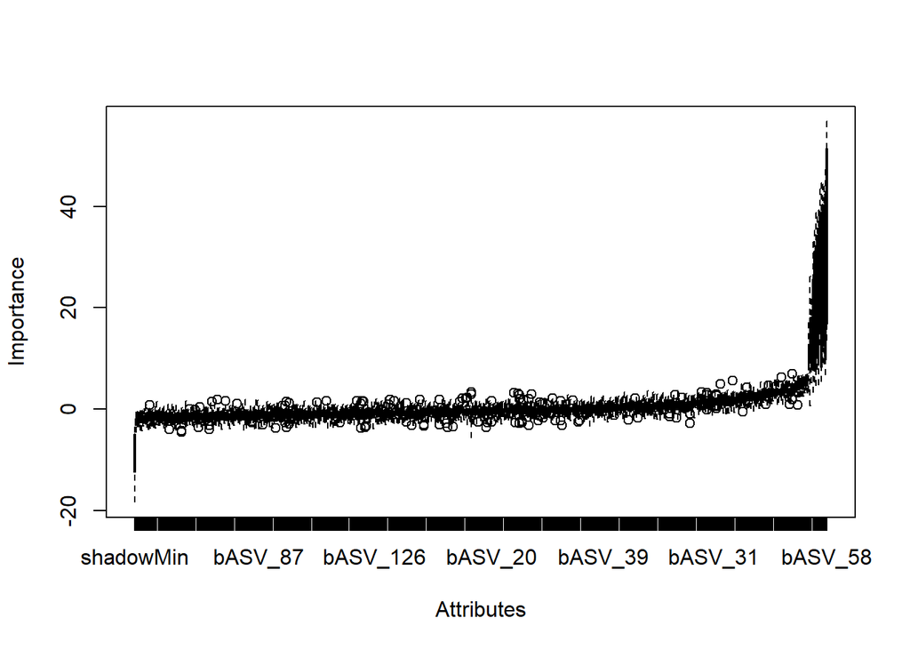

```r
# check a boxplot of feature importance
plot(boruta_output_stress)
```

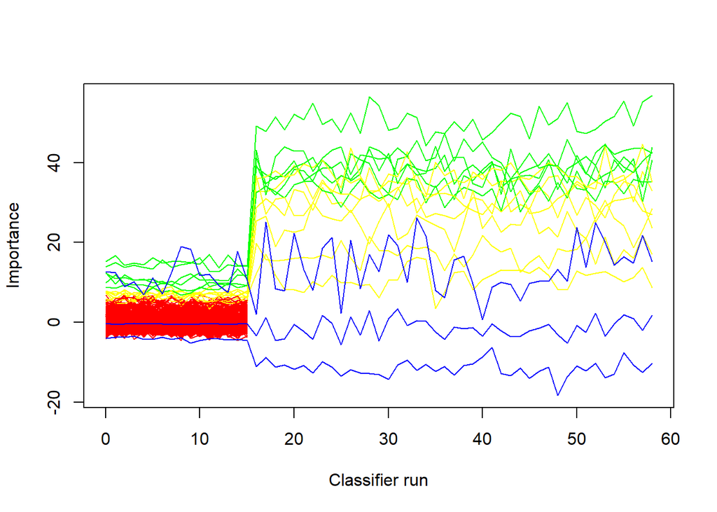

```r
# check feature imortance over itetations
plotImpHistory(boruta_output_stress)
```

```r
# you can force a solution to tentative features
boruta_output_stress_fixed<-TentativeRoughFix(boruta_output_stress)

# you can now get the features intoa  formula format
boruta_output_stress_fixed_formula<-getConfirmedFormula(boruta_output_stress_fixed)
```